# Is the acquisition of a habit-like knowledge associated with general cognitice performance?

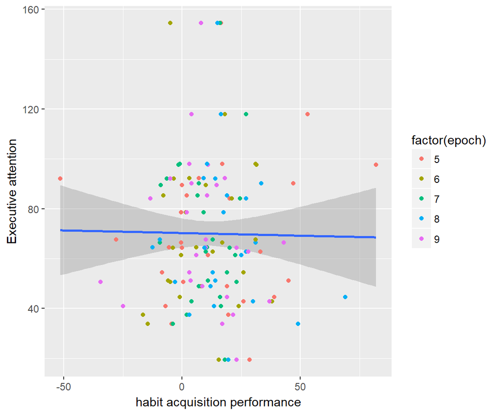

```r
ggplot(gsrt_corr_habit) +
  geom_smooth(method = lm, mapping = aes(y = ant_executive, x = LH_dif_rt)) +
  geom_point(mapping = aes(y = ant_executive, x = LH_dif_rt, color = factor(epoch))) +
  labs(y = "Executive attention", x = "habit acquisition performance")
```

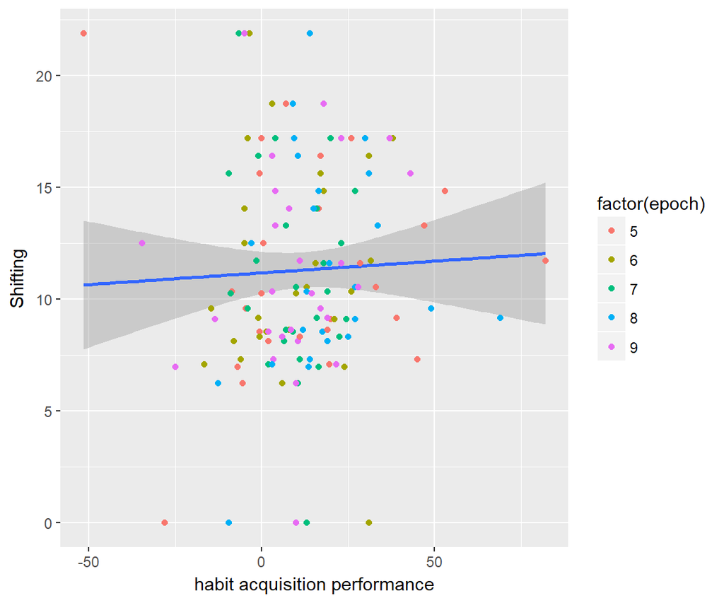

```r
ggplot(gsrt_corr_habit) +
  geom_smooth(method = lm, mapping = aes(y = wcst_pers_error_rate, x = LH_dif_rt)) +
  geom_point(mapping = aes(y = wcst_pers_error_rate, x = LH_dif_rt, color = factor(epoch))) +
  labs(y = "Shifting", x = "habit acquisition performance")
```

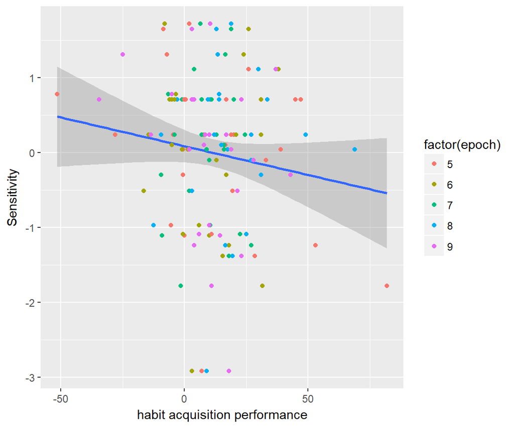

```r
ggplot(gsrt_corr_habit) +
  geom_smooth(method = lm, mapping = aes(y = gng_dprime, x = LH_dif_rt)) +
  geom_point(mapping = aes(y = gng_dprime, x = LH_dif_rt, color = factor(epoch))) +
  labs(y = "Sensitivity", x = "habit acquisition performance")
```

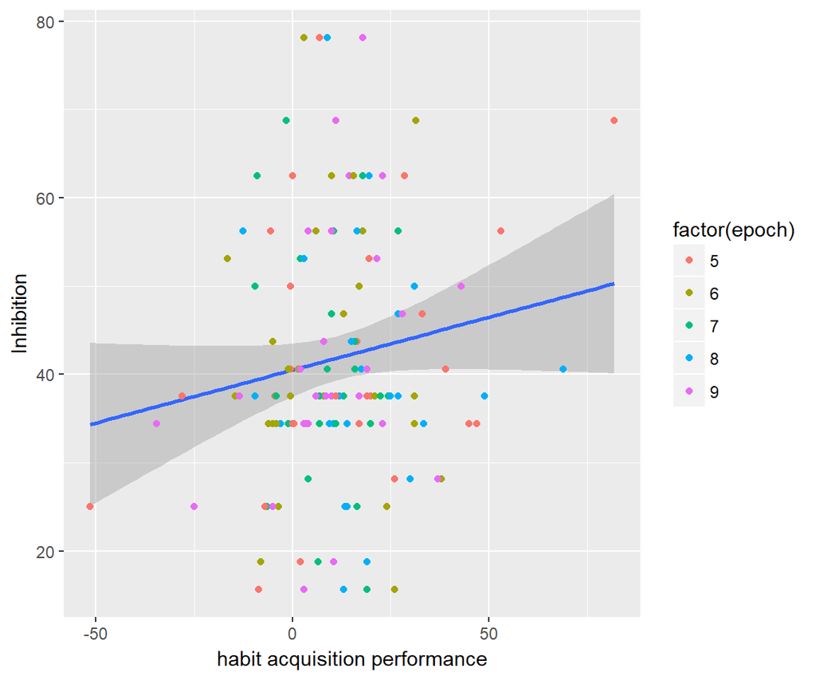

```r
ggplot(gsrt_corr_habit) +
  geom_smooth(method = lm, mapping = aes(y = gng_false_alarm_rate, x = LH_dif_rt)) +
  geom_point(mapping = aes(y = gng_false_alarm_rate, x = LH_dif_rt, color = factor(epoch))) +
  labs(y = "Inhibition", x = "habit acquisition performance")
```

[figure not shown]

```r
ggplot(gsrt_corr_habit) +
  geom_smooth(method = lm, mapping = aes(y = avg_rt, x = LH_dif_rt)) +
  geom_point(mapping = aes(y = avg_rt, x = LH_dif_rt, color = factor(epoch))) +
  labs(y = "accuracy", x = "habit acquisition performance")
```

[figure not shown]

```r
ggplot(gsrt_corr_habit) +
  geom_smooth(method = lm, mapping = aes(y = avg_acc, x = LH_dif_rt)) +
  geom_point(mapping = aes(y = avg_acc, x = LH_dif_rt, color = factor(epoch))) +
  labs(y = "reaction time", x = "habit acquisition performance")
```

### 0.4.2 Correlational analysis

Spearman correlations were conducted due to normalality violation and the lack of expectations for truly linear relationships. We found no significant and at least moderately strong correlation.

```r
gsrt_corr_learning <- gsrt_plot %>%
  filter(block == 1 | block == 6 | block == 11 |
         block == 16 | block == 21 | block == 26 |
         block == 31 | block == 36 | block == 41) %>%
  filter(epoch <= 4) %>%
  drop_na()

gsrt_corr_habit <- gsrt_plot %>%
  filter(block == 1 | block == 6 | block == 11 |
           block == 16 | block == 21 | block == 26 |
           block == 31 | block == 36 | block == 41) %>%
  filter(epoch > 4) %>%
  drop_na()

shapiro.test(gsrt_anova$digit_span)
```

```
##
##  Shapiro-Wilk normality test
##
## data:  gsrt_anova$digit_span
## W = 0.89477, p-value < 2.2e-16
```

```r
shapiro.test(gsrt_anova$counting_span)
```

```
##
##  Shapiro-Wilk normality test
##
## data:  gsrt_anova$counting_span
## W = 0.96308, p-value < 2.2e-16
```

```r
shapiro.test(gsrt_anova$running_span)
```

```
##
##  Shapiro-Wilk normality test
##
## data:  gsrt_anova$running_span
## W = 0.90555, p-value < 2.2e-16
```

```r
shapiro.test(gsrt_anova$wcst_pers_error_rate)
```

```
##
##  Shapiro-Wilk normality test
##
## data:  gsrt_anova$wcst_pers_error_rate
## W = 0.95479, p-value < 2.2e-16
```

```r
shapiro.test(gsrt_anova$ant_orienting)
```

```
##
##  Shapiro-Wilk normality test
##
## data:  gsrt_anova$ant_orienting
## W = 0.96234, p-value < 2.2e-16
```

```r
shapiro.test(gsrt_anova$ant_alerting)
```

```
##
##  Shapiro-Wilk normality test
##
## data:  gsrt_anova$ant_alerting
## W = 0.96526, p-value < 2.2e-16
```

```r
shapiro.test(gsrt_anova$ant_executive)
```

```
##
##  Shapiro-Wilk normality test
##
## data:  gsrt_anova$ant_executive
## W = 0.94415, p-value < 2.2e-16
```

```r
shapiro.test(gsrt_anova$gng_dprime)
```

```
##
##  Shapiro-Wilk normality test
##
## data:  gsrt_anova$gng_dprime
## W = 0.90469, p-value < 2.2e-16
```

```r
shapiro.test(gsrt_anova$gng_false_alarm_rate)
```

```
##
##  Shapiro-Wilk normality test
##
## data:  gsrt_anova$gng_false_alarm_rate
## W = 0.94689, p-value < 2.2e-16
```

```r
shapiro.test(gsrt_anova$avg_rt)
```

```
##
##  Shapiro-Wilk normality test
##
## data:  gsrt_anova$avg_rt
## W = 0.99058, p-value = 2.025e-07
```

```r
shapiro.test(gsrt_anova$avg_acc)
```

```
##
##  Shapiro-Wilk normality test
##
## data:  gsrt_anova$avg_acc
## W = 0.94923, p-value < 2.2e-16
```

```r
cor.test(gsrt_corr_learning$LH_dif_rt, gsrt_corr_learning$digit_span,
         method = "spearman")
```

```
##
##  Spearman's rank correlation rho
##
## data:  gsrt_corr_learning$LH_dif_rt and gsrt_corr_learning$digit_span
## S = 180790, p-value = 0.1519
## alternative hypothesis: true rho is not equal to 0
## sample estimates:
##       rho
## 0.1388397
```

```r
cor.test(gsrt_corr_learning$LH_dif_rt, gsrt_corr_learning$counting_span,
         method = "spearman")
```

```
##
##  Spearman's rank correlation rho
##
## data:  gsrt_corr_learning$LH_dif_rt and gsrt_corr_learning$counting_span
## S = 191990, p-value = 0.3792
## alternative hypothesis: true rho is not equal to 0
## sample estimates:
##       rho
## 0.0854608
```

```r
cor.test(gsrt_corr_learning$LH_dif_rt, gsrt_corr_learning$running_span,
         method = "spearman")
```

```
##
##  Spearman's rank correlation rho
##
## data:  gsrt_corr_learning$LH_dif_rt and gsrt_corr_learning$running_span
## S = 212320, p-value = 0.9069
## alternative hypothesis: true rho is not equal to 0
## sample estimates:
##         rho
## -0.01138867
```

```r
cor.test(gsrt_corr_learning$LH_dif_rt, gsrt_corr_learning$ant_orienting,
         method = "spearman")
```

```
##
##  Spearman's rank correlation rho
##
## data:  gsrt_corr_learning$LH_dif_rt and gsrt_corr_learning$ant_orienting
## S = 174640, p-value = 0.08201
## alternative hypothesis: true rho is not equal to 0
## sample estimates:
##       rho
## 0.1681094
```

```r
cor.test(gsrt_corr_learning$LH_dif_rt, gsrt_corr_learning$ant_alerting,
         method = "spearman")
```

```
##
##  Spearman's rank correlation rho
##
## data:  gsrt_corr_learning$LH_dif_rt and gsrt_corr_learning$ant_alerting
## S = 179350, p-value = 0.1325
## alternative hypothesis: true rho is not equal to 0
## sample estimates:
##       rho
## 0.1456872
```

```r
cor.test(gsrt_corr_learning$LH_dif_rt, gsrt_corr_learning$ant_executive,
         method = "spearman")
```

```
##
##  Spearman's rank correlation rho
##
## data:  gsrt_corr_learning$LH_dif_rt and gsrt_corr_learning$ant_executive
## S = 203930, p-value = 0.7687
## alternative hypothesis: true rho is not equal to 0
## sample estimates:
##        rho
## 0.02862258
```

```r
cor.test(gsrt_corr_learning$LH_dif_rt, gsrt_corr_learning$wcst_pers_error_rate,
         method = "spearman")
```

```
##
##  Spearman's rank correlation rho
##
## data:  gsrt_corr_learning$LH_dif_rt and gsrt_corr_learning$wcst_pers_error_rate
## S = 200870, p-value = 0.6574
## alternative hypothesis: true rho is not equal to 0
## sample estimates:
##        rho
## 0.04315975
```

```r
cor.test(gsrt_corr_learning$LH_dif_rt, gsrt_corr_learning$gng_dprime,
         method = "spearman")
```

```
##
##  Spearman's rank correlation rho
##
## data:  gsrt_corr_learning$LH_dif_rt and gsrt_corr_learning$gng_dprime
## S = 254660, p-value = 0.02684
## alternative hypothesis: true rho is not equal to 0
## sample estimates:
##        rho
## -0.2130482
```

```r
cor.test(gsrt_corr_learning$LH_dif_rt, gsrt_corr_learning$gng_false_alarm_rate,
         method = "spearman")
```

```
##
##  Spearman's rank correlation rho
##
## data:  gsrt_corr_learning$LH_dif_rt and gsrt_corr_learning$gng_false_alarm_rate
## S = 170700, p-value = 0.05276
## alternative hypothesis: true rho is not equal to 0
## sample estimates:
##       rho
## 0.1869057
```

```r
cor.test(gsrt_corr_learning$LH_dif_rt, gsrt_corr_learning$avg_rt,
         method = "spearman")
```

```
##
##  Spearman's rank correlation rho
##
## data:  gsrt_corr_learning$LH_dif_rt and gsrt_corr_learning$avg_rt
## S = 229430, p-value = 0.3392
## alternative hypothesis: true rho is not equal to 0
## sample estimates:
##         rho
## -0.09285134
```

```r
cor.test(gsrt_corr_learning$LH_dif_rt, gsrt_corr_learning$avg_acc,
         method = "spearman")
```

```
##
##  Spearman's rank correlation rho
##
## data:  gsrt_corr_learning$LH_dif_rt and gsrt_corr_learning$avg_acc
## S = 220070, p-value = 0.6196
## alternative hypothesis: true rho is not equal to 0
## sample estimates:
##         rho
## -0.04830216
```

```r
cor.test(gsrt_corr_habit$LH_dif_rt, gsrt_corr_habit$digit_span,
         method = "spearman")
```

```
##
##  Spearman's rank correlation rho
##
## data:  gsrt_corr_habit$LH_dif_rt and gsrt_corr_habit$digit_span
## S = 364500, p-value = 0.1997
## alternative hypothesis: true rho is not equal to 0
## sample estimates:
##       rho
## 0.1110581
```

```r
cor.test(gsrt_corr_habit$LH_dif_rt, gsrt_corr_habit$counting_span,
         method = "spearman")
```

```
##
##  Spearman's rank correlation rho
##
## data:  gsrt_corr_habit$LH_dif_rt and gsrt_corr_habit$counting_span
## S = 409530, p-value = 0.9886
## alternative hypothesis: true rho is not equal to 0
## sample estimates:
##        rho
## 0.00124344
```

```r
cor.test(gsrt_corr_habit$LH_dif_rt, gsrt_corr_habit$running_span,
         method = "spearman")
```

```
##
##  Spearman's rank correlation rho
##
## data:  gsrt_corr_habit$LH_dif_rt and gsrt_corr_habit$running_span
## S = 427740, p-value = 0.6191
## alternative hypothesis: true rho is not equal to 0
## sample estimates:
##         rho
## -0.04316732
```

```r
cor.test(gsrt_corr_habit$LH_dif_rt, gsrt_corr_habit$ant_orienting,
         method = "spearman")
```

```
##
##  Spearman's rank correlation rho
##
## data:  gsrt_corr_habit$LH_dif_rt and gsrt_corr_habit$ant_orienting
## S = 374800, p-value = 0.3216
## alternative hypothesis: true rho is not equal to 0
## sample estimates:
##        rho
## 0.08595165
```

```r
cor.test(gsrt_corr_habit$LH_dif_rt, gsrt_corr_habit$ant_alerting,
         method = "spearman")
```

```
##
##  Spearman's rank correlation rho
##
## data:  gsrt_corr_habit$LH_dif_rt and gsrt_corr_habit$ant_alerting
## S = 365790, p-value = 0.2128
## alternative hypothesis: true rho is not equal to 0
## sample estimates:
##       rho
## 0.1079174
```

```r
cor.test(gsrt_corr_habit$LH_dif_rt, gsrt_corr_habit$ant_executive,
         method = "spearman")
```

```
##
##  Spearman's rank correlation rho
##
## data:  gsrt_corr_habit$LH_dif_rt and gsrt_corr_habit$ant_executive
## S = 431040, p-value = 0.5553
## alternative hypothesis: true rho is not equal to 0
## sample estimates:
##         rho
## -0.05120677
```

```r
cor.test(gsrt_corr_habit$LH_dif_rt, gsrt_corr_habit$wcst_pers_error_rate,
         method = "spearman")
```

```
##
##  Spearman's rank correlation rho
##
## data:  gsrt_corr_habit$LH_dif_rt and gsrt_corr_habit$wcst_pers_error_rate
## S = 360930, p-value = 0.1664
## alternative hypothesis: true rho is not equal to 0
## sample estimates:
##       rho
## 0.1197794
```

```r
cor.test(gsrt_corr_habit$LH_dif_rt, gsrt_corr_habit$gng_dprime,
         method = "spearman")
```

```
##
##  Spearman's rank correlation rho
##
## data:  gsrt_corr_habit$LH_dif_rt and gsrt_corr_habit$gng_dprime
## S = 464200, p-value = 0.1268
## alternative hypothesis: true rho is not equal to 0
## sample estimates:
##        rho
## -0.1320725
```

```r
cor.test(gsrt_corr_habit$LH_dif_rt, gsrt_corr_habit$gng_false_alarm_rate,
         method = "spearman")
```

```
##
##  Spearman's rank correlation rho
##
## data:  gsrt_corr_habit$LH_dif_rt and gsrt_corr_habit$gng_false_alarm_rate
## S = 359440, p-value = 0.1539
## alternative hypothesis: true rho is not equal to 0
## sample estimates:
##       rho
## 0.1234117
```

```r
cor.test(gsrt_corr_habit$LH_dif_rt, gsrt_corr_habit$avg_rt,
         method = "spearman")
```

```
##
##  Spearman's rank correlation rho
##
## data:  gsrt_corr_habit$LH_dif_rt and gsrt_corr_habit$avg_rt
## S = 474820, p-value = 0.06723
## alternative hypothesis: true rho is not equal to 0
## sample estimates:
##        rho
## -0.1579926
```

```r
cor.test(gsrt_corr_habit$LH_dif_rt, gsrt_corr_habit$avg_acc,
         method = "spearman")
```

```
##
##  Spearman's rank correlation rho
##
## data:  gsrt_corr_habit$LH_dif_rt and gsrt_corr_habit$avg_acc
## S = 445640, p-value = 0.3167
## alternative hypothesis: true rho is not equal to 0
## sample estimates:
##         rho
## -0.08681706
```

## 0.5 Conclusions

Our results are in line with our hypothesis, that similarly to the learning of the knowledge behind a habit-like behavior, the acqusition of the habit itself is not associated with general cogntive performance, suggesting that the extraction of statistical patterns and building automatic responses based on these patterns takes place at another level then higher-order human abilities in our processing system.